# Cluster Analysis: Marketing to Frequent Fliers

Matt Briskey

2022-10-15

Problem 4 - Airline Frequent Fliers

**A. Apply hierarchical clustering with Euclidean distance and Ward’s method. Make sure to normalize the data first. How many clusters appear?**

Read the file

```r
input<- read.csv("G:/My Drive/MSDA/DATA 610 Big Data Analytics/Rdata/Rdata/EastWestAirlinesCluster.csv",header=TRUE)
```

Exclude unwanted columns

```r
mydata<- input[1:3999,2:12]
```

Normmalize the data

```r
normalized_data<- scale(mydata)
```

Calculate the euclidean distance using Ward’s method

```r
d <- dist(normalized_data, method = "euclidean")
fit <- hclust(d, method="ward.D2")
```

Display the dendrogram and outline the three clusters in blue

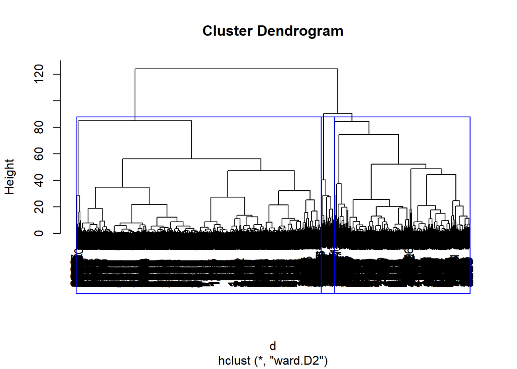

```r
plot(fit)
rect.hclust(fit, k=3, border="blue")
```

*Three clusters appear as can be seen in the dendrogram above.*

**B. What would happen if the data were not normalized?**

*If the data weren’t normalized, the data with larger values/scale will skew the distance calculated and therefore the clusters.*

**C. Compare the cluster centroid to characterize the different clusters, and try to give each cluster a label.**

```r
d <- dist(normalized_data, method = "euclidean")
fit <- hclust(d, method="complete")
options(scipen=99999999)

groups <- cutree(fit, k=3)

clust.centroid = function(i, dat, groups) {
  ind = (groups == i)
  colMeans(dat[ind,])
}
sapply(unique(groups), clust.centroid, mydata, groups)
```

```
##                            [,1]           [,2]      [,3]
## Balance           73299.6959799 138061.4000000 131999.50
## Qual_miles          144.1567839     78.8000000    347.00
## cc1_miles             2.0537688      3.4666667      2.50
## cc2_miles             1.0145729      1.0000000      1.00
## cc3_miles             1.0007538      4.0666667      1.00
## Bonus_miles       16806.7298995  93927.8666667  65634.25
## Bonus_trans          11.4819095     28.0666667     69.25
## Flight_miles_12mo   440.2821608    506.6666667  19960.00
## Flight_trans_12       1.3246231      1.6000000     49.25
## Days_since_enroll  4118.6206030   4613.8666667   2200.25
## Award.                0.3690955      0.5333333      1.00
```

**D. To check the stability of clusters, remove a random 5% of the data x (by taking a random sample of 95% of the records), and repeat the analysis. Does the same picture emerge?**

Outline the three clusters in blue

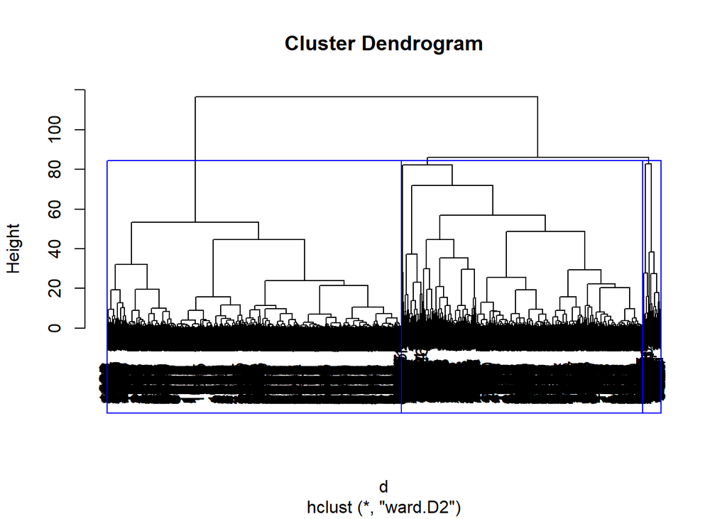

```r
normalized_data_95 <- scale(mydata[sample(nrow(mydata), nrow(mydata)*.95), ])
d <- dist(normalized_data_95, method = "euclidean")
fit <- hclust(d, method="ward.D2")
plot(fit)
rect.hclust(fit, k=3, border="blue")
```

```r
clust.centroid = function(i, dat, groups) {
  ind = (groups == i)
  colMeans(dat[ind,])
}
sapply(unique(groups), clust.centroid, mydata, groups)
```

```
##                            [,1]           [,2]      [,3]
## Balance           73299.6959799 138061.4000000 131999.50
## Qual_miles          144.1567839     78.8000000    347.00
## cc1_miles             2.0537688      3.4666667      2.50
## cc2_miles             1.0145729      1.0000000      1.00
## cc3_miles             1.0007538      4.0666667      1.00
## Bonus_miles       16806.7298995  93927.8666667  65634.25
## Bonus_trans          11.4819095     28.0666667     69.25
## Flight_miles_12mo   440.2821608    506.6666667  19960.00
## Flight_trans_12       1.3246231      1.6000000     49.25
## Days_since_enroll  4118.6206030   4613.8666667   2200.25
## Award.                0.3690955      0.5333333      1.00
```

**E. Use k-means clustering with the number of clusters that you found above. Does the same picture emerge?**

```r
fit <- kmeans(mydata, centers=3, iter.max=10)
t(fit$centers)
```

```
##                                1             2            3
## Balance           563233.2222222 36759.9743425 167615.27250
## Qual_miles           451.9259259   104.6905067    266.60375
## cc1_miles              3.2222222     1.7854394      3.01000
## cc2_miles              1.0370370     1.0153945      1.00875
## cc3_miles              1.0370370     1.0076972      1.02750
## Bonus_miles        53100.8518519 11901.0041693  33942.17500
## Bonus_trans           20.4444444     9.9268762     17.23500
## Flight_miles_12mo   1758.1234568   309.5686337    915.15000
## Flight_trans_12        5.7037037     0.9278384      2.67250
## Days_since_enroll   6203.7530864  3854.8710712   4935.15875
## Award.                 0.7901235     0.3316228      0.47875
```

*The same picture does not emerge using k-means clustering. The k-means clusters can be seen above.*

**F. Which clusters would you target for offers, and what types of offers would you target to customers in that cluster?**

*I would target the k-means cluster #1 because they have the largest balance and have been enrolled in the program the longest so they are more likely the frequent fliers.*